# How reproducible is ecology?

Aud and Matt

## Reproducibilty

[figure not shown]

The Turing Way Community. This illustration is created by Scriberia with The Turing Way community, used under a CC-BY 4.0 licence. DOI: 10.5281/zenodo.3332807

## 7 BES journals (2017 - 2024)

- Does the paper use data/code? If so, are they archived?
- Where were the data/code archived?
- Can the archived data/code be located, downloaded and opened?
- What file extensions do the archived data/code files use?
- Do the archived data/code have a README (or equivalent)? If so, how useful is it?
- How complete is the archived data?
- How good is the code annotation?
- Are the data/code citable?

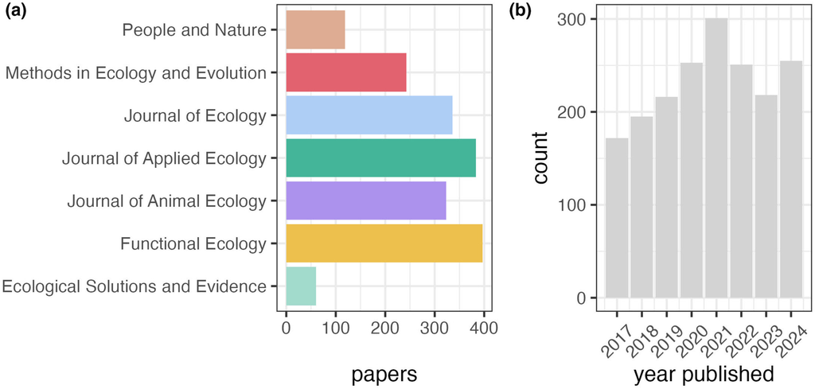

## Is the data/code archived?

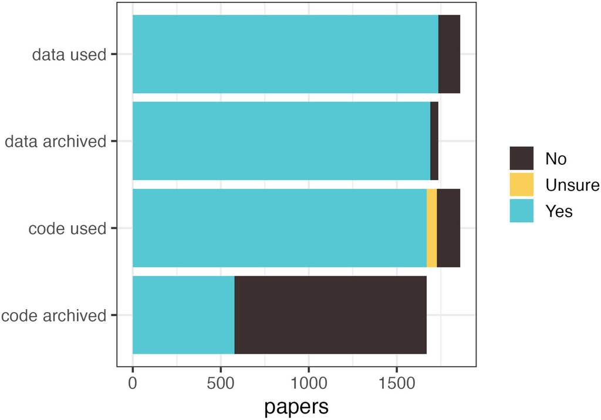

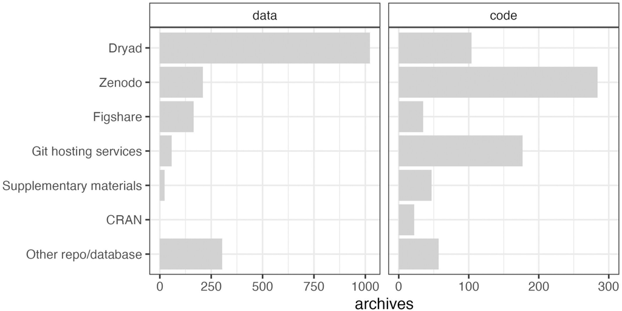

## Located, downloaded and opened?

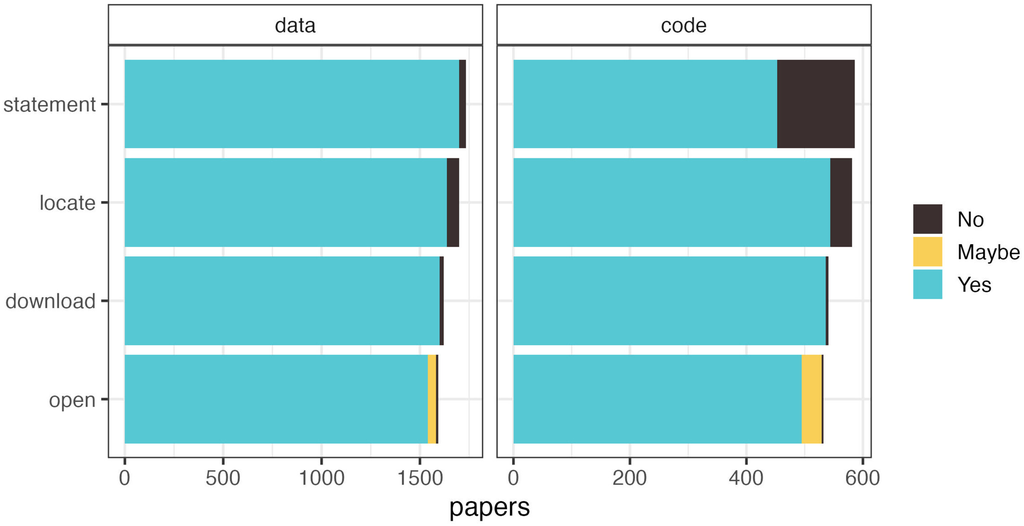

## File extensions

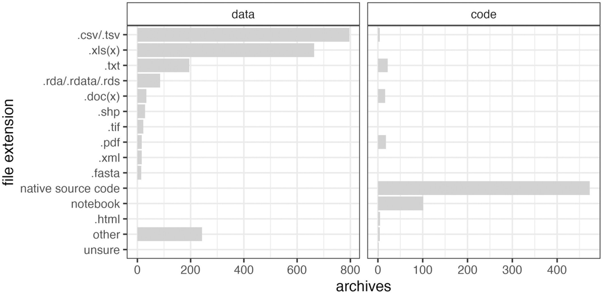

## Readme

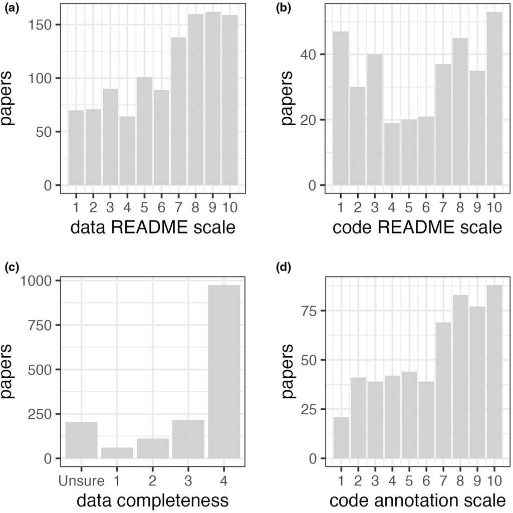

## Reviewed papers from 6 journals (2023-2025)

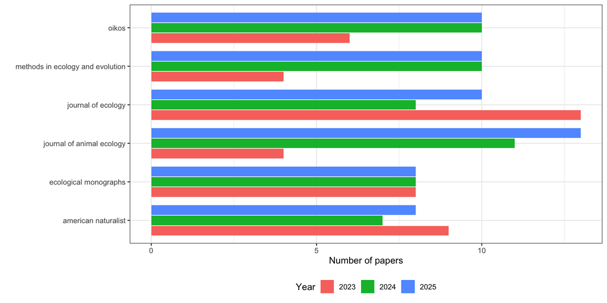

### Data and code availability (2023–2025)

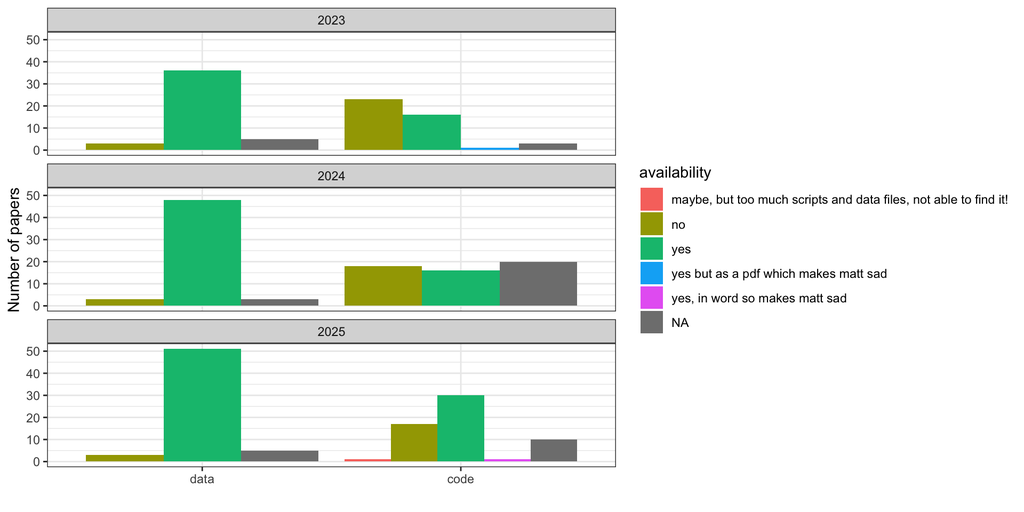

Figure 2: Data and code availability by year.

### 2023–2025: data and code availability by journal

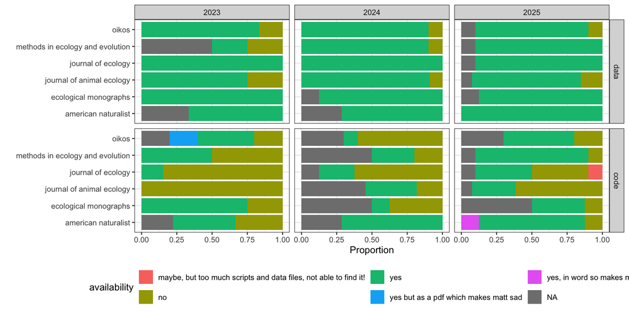

Figure 3

## Exercise (1/2)

Make 6 groups.

Choose one of the following journals and select a random issue from 2026:

- Methods in Ecology and Evolution
- Journal of Ecology
- OIKOS
- American Naturalist
- Journal of Animal Ecology
- Ecological Monographs

## Exercise (2/2)

For each paper in this issue check:

- Is the **data available** and can you download it? Repo or supplement file? In what format is the data available (xlsx, csv, txt, etc.)?
- Is the **code available**? Choose one figure/analysis. Is the data and code for this figure/analysis available? Try to run the code, can you replicate the figure/analysis.
- Add the data to this [google spreadsheet](https://docs.google.com/spreadsheets/d/1Rde3TsuFsExDmNNROZqslWVUOl_dXaLp4V-LnHq3Fyw/edit?gid=1921182395#gid=1921182395) and get a snack 🍪